# National Transit Database - 2015 Service Analysis

Ruzbeh Shokranian

February 7, 2017

## National Transit Database Data Exploration

This document describes the analysis that was done on the National Transit Database (NTD) 2015 service data. The NTD program collects data from several transit agencies in the United States and is the primary source for transit data.The specific dataset that will be analysed in this project correspond to 2015 service data organized by agency, mode and type of service. The original dataset can be found on this link: https://www.transit.dot.gov/ntd/data-product/2015-service The excel file was downloaded and sheet “Annual Service Data by Mode” was saved in csv format and used in this project. The original excel dataset is attached with this project and it includes a sheet labeled “Data Dictionary” which describes each variable in the data.

The dataset includes information on several variables for many transit agencies. Some of the variables include the number of annual trips, transit performance measures, revenue statistics and more. Starting the data exploration, a few plots will be made.

## Unlinked Trips by Mode

To start, annual unlinked trips by mode will be plotted. Unlinked trips are defined as the number of passengers that board or alight a transit vehicle, even if the boarding/alighting correspond to a transfer.

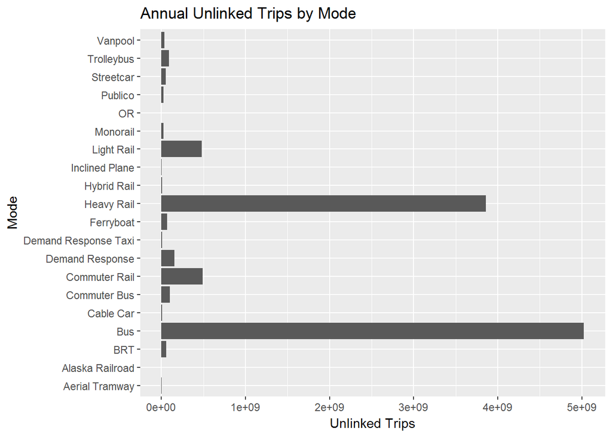

Note that Bus and Heavy Rail correspond to the modes with the highest ridership.

## State Analysis

The graph below shows annual unlinked trips grouped by state. The state with the highest transit ridership corresponds to New York.

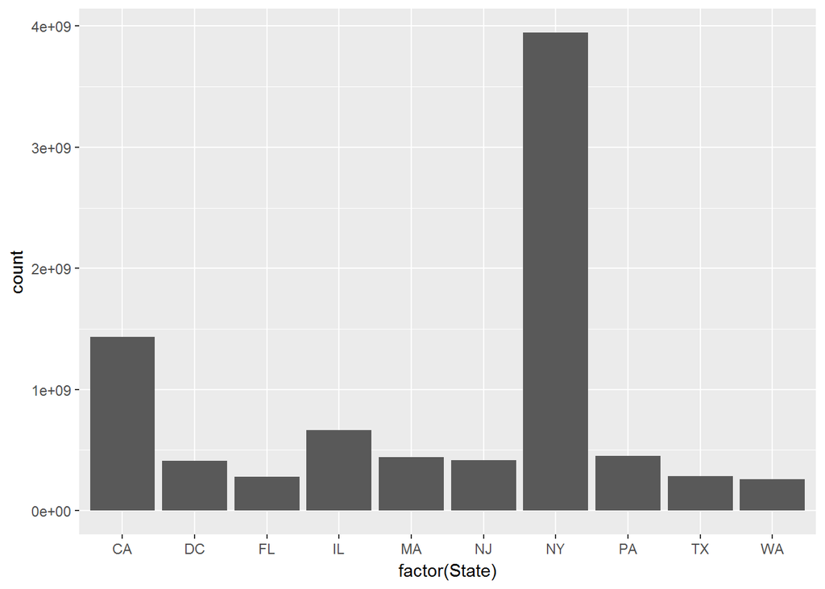

Below some summary statistics for unlinked trips by States are presented:

```r
summary(ntd_unlinked_trips_by_state$trips)
```

```
##      Min.   1st Qu.    Median      Mean   3rd Qu.      Max.
## 8.210e+02 7.004e+06 3.491e+07 1.874e+08 1.167e+08 3.946e+09
```

## City Analysis

The data includes the city in which each agency is located. First, some descriptive statistics of the number of unlinked trips per city and total passenger miles per city (defined as the number of miles that passengers travel) will be shown.

```r
summary(ntd_data_by_city$trips)
```

```
##      Min.   1st Qu.    Median      Mean   3rd Qu.      Max.
## 1.510e+02 2.448e+04 9.878e+04 6.428e+06 5.855e+05 3.683e+09
```

```r
summary(ntd_data_by_city$passenger_miles)
```

```
##      Min.   1st Qu.    Median      Mean   3rd Qu.      Max.
## 0.000e+00 0.000e+00 0.000e+00 3.411e+07 2.771e+05 1.551e+10
```

The range of both variables is very high, with the mean and the median having very different values. This is because there are several outliers in the data. To better understand these variables the histograms below explore the trips and passenger miles variables, respectively. A log transformation was used to improve visualization.

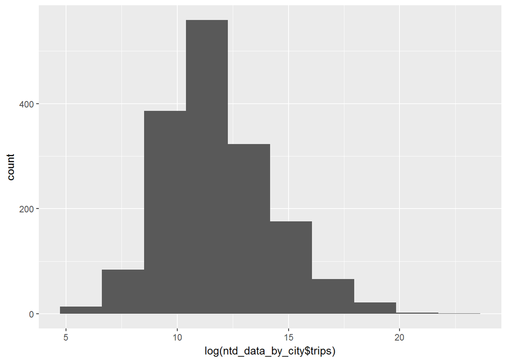

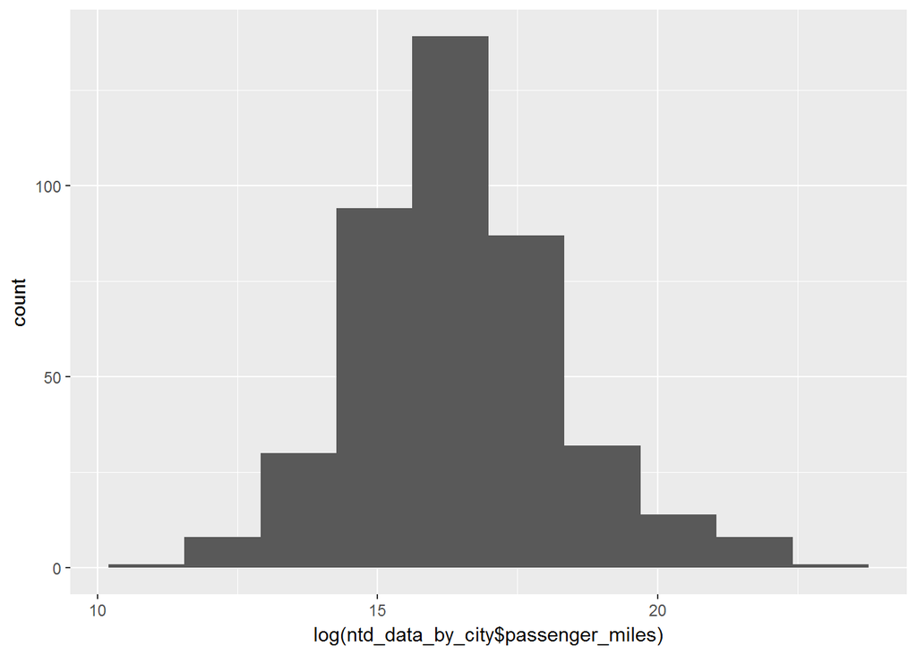

The graphs below presents the number of unlinked trips per city and total passenger miles per city, respectively. The graphs are shown for the top 10 cities.

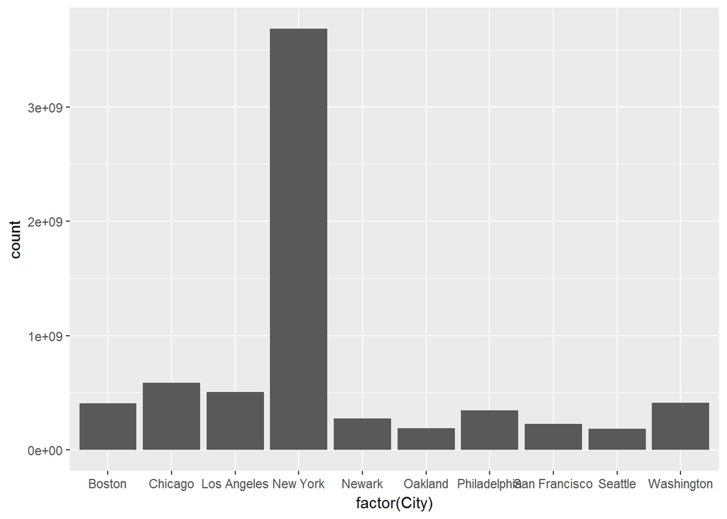

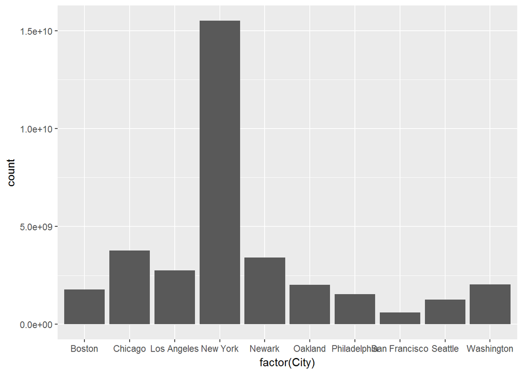

Both graphs above are very similar, indicating that there is a strong relationship between total unlinked trips and passenger miles. The scatter plot below shows that this relationship does in fact exist.

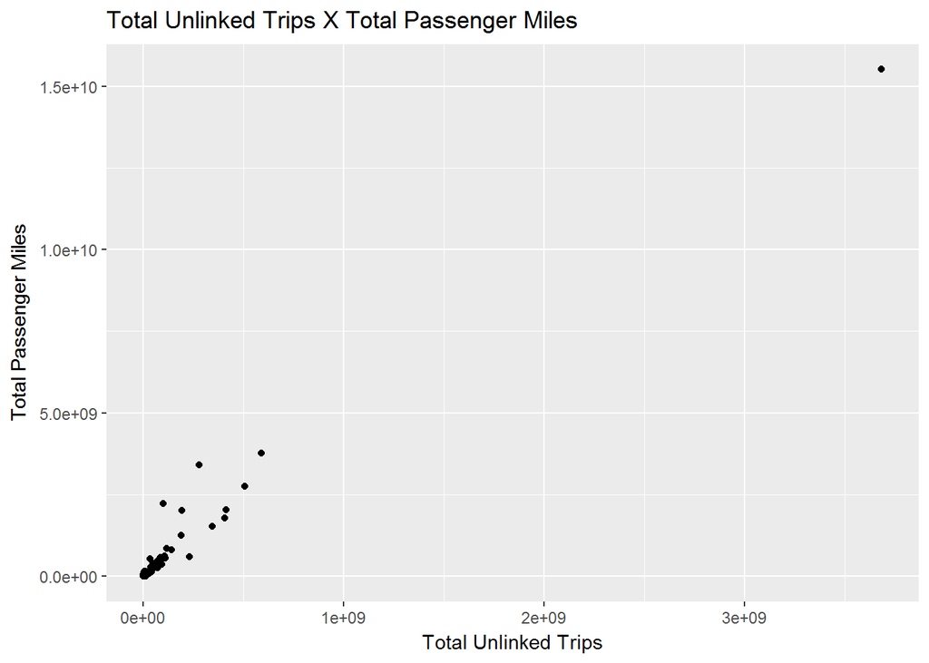

In the graph above, the point in the top right corner corresponds to New York City. Below, the same graph is plotted without NYC so it is possible to take a close look at the other cities. The graph indicates that although there is a relationship between both variables, there are a few cities where that relationship is weaker.

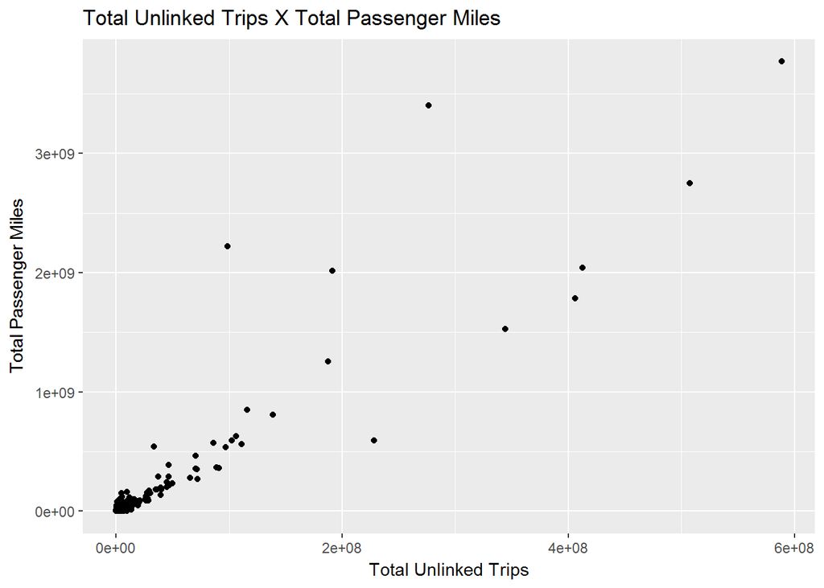

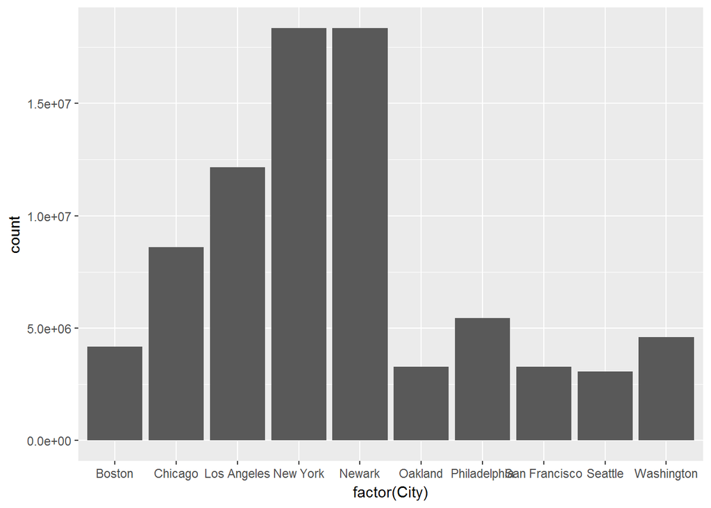

And here are some descriptive statistics of cities population:

```r
summary(ntd_data_by_city$city_population)
```

```
##     Min.  1st Qu.   Median     Mean  3rd Qu.     Max.
##        0        0        0   946500   202600 18350000
```

And the city population histogram below. A log transformation is applied to better represent the population distribution.

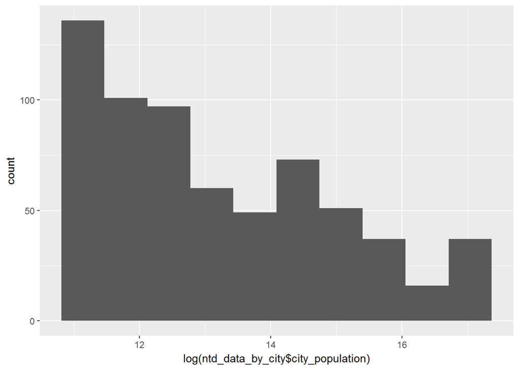

And the scatter plot below shows how they are related:

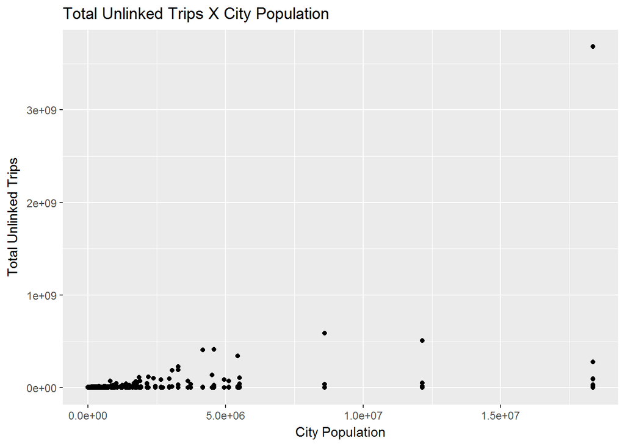

## Vehicle Hours X Vehicle Miles

Vehicle Hours correspond to the number of hours that a vehicle travels while in service. Similarly, Vehicle Miles correspond to the number of miles that the vehicle travels while in service.

The statistics below show how this variable varies across the dataset:

```r
summary(ntd_service_data$Vehicle.Miles)
```

```
##      Min.   1st Qu.    Median      Mean   3rd Qu.      Max.
##         0         0         0   1275000    392600 356200000
```

```r
summary(ntd_service_data$Vehicle.Hours)
```

```
##     Min.  1st Qu.   Median     Mean  3rd Qu.     Max.
##        0        0        0    83660    24920 19950000
```

The scatter plot below is an attempt to see if there is a relationship between both variables. The plot applies a log transformation to each of these variables in an attempt to better represent the results and to deal with outliers.

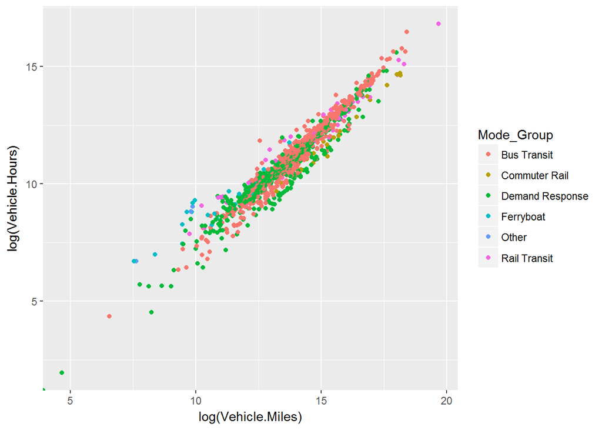

Each color in the graph corresponds to a different group of modes (similar modes are grouped together), and it appears that the relationship is different for each mode group. Some of them seem to have a stronger relationship them others.

Continuing the exploration of vehicle related variables, the multivariate plot below explores the relationshipt between three variables: Vehicle Hours, Vehicle Miles, and the Number of Vehicles, represented by diferent colors. As expected all of them are related.

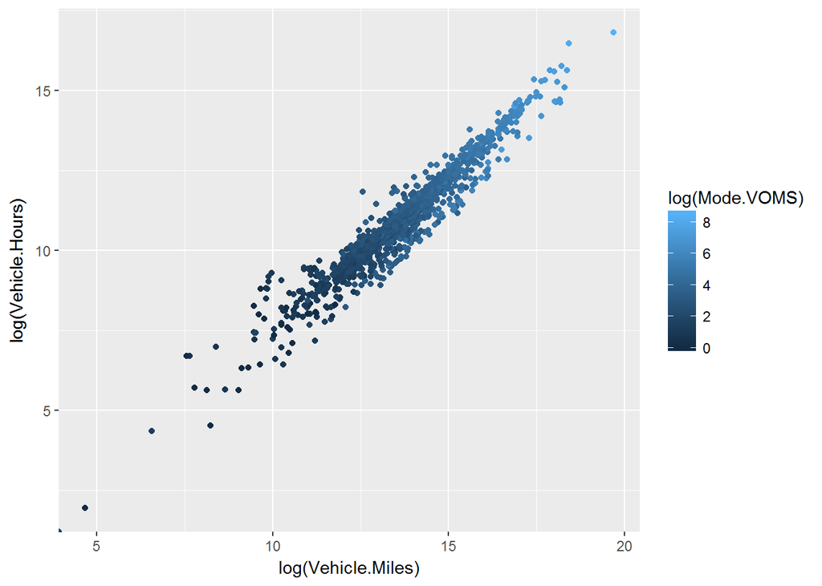

To better present the relationship between Vehicle Hours & Miles for each mode, a new variable will be created: the ratio of Vehicle Miles and Vehicle Hours. The bar plot below presents this ratio for each mode.

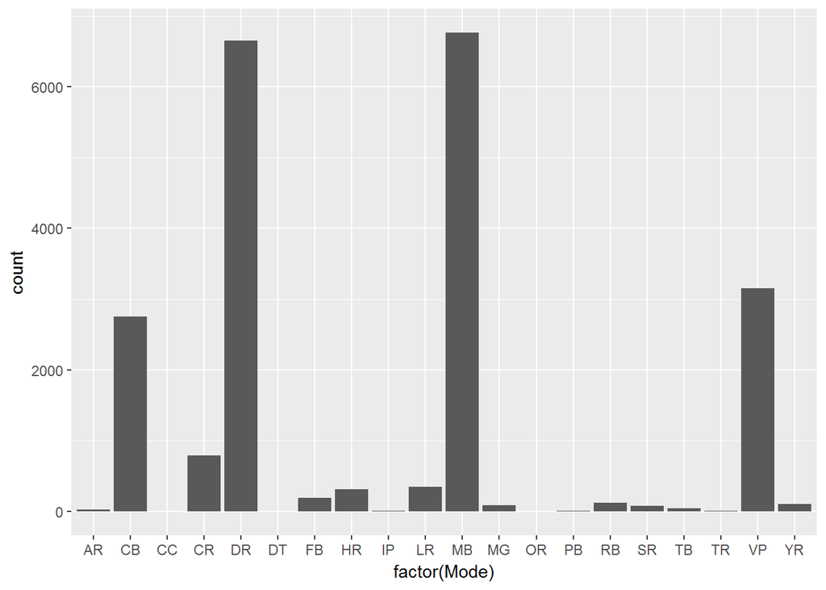

The bar plot above shows that the ratio is very different for each mode. Modes such as Demand Response (DR) and Bus (MB) have a higher ratio. To confirm the correlation between both variables we will perform a Pearson’s Test, which results in a 0.93 correlation.

```r
cor.test(ntd_service_data$Vehicle.Miles,ntd_service_data$Vehicle.Hours,
         method = "pearson")
```

```
##
##  Pearson's product-moment correlation
##
## data:  ntd_service_data$Vehicle.Miles and ntd_service_data$Vehicle.Hours
## t = 156.84, df = 3525, p-value < 2.2e-16
## alternative hypothesis: true correlation is not equal to 0
## 95 percent confidence interval:
##  0.9309631 0.9392447
## sample estimates:
##       cor
## 0.9352317
```

## Commuter Rail

In this section Commuter Rail will be specifically analysed. The bar chart below presents the top 10 commuter rail agencies in the US. Note that the 3 biggest serve the New York City metropolitan area.

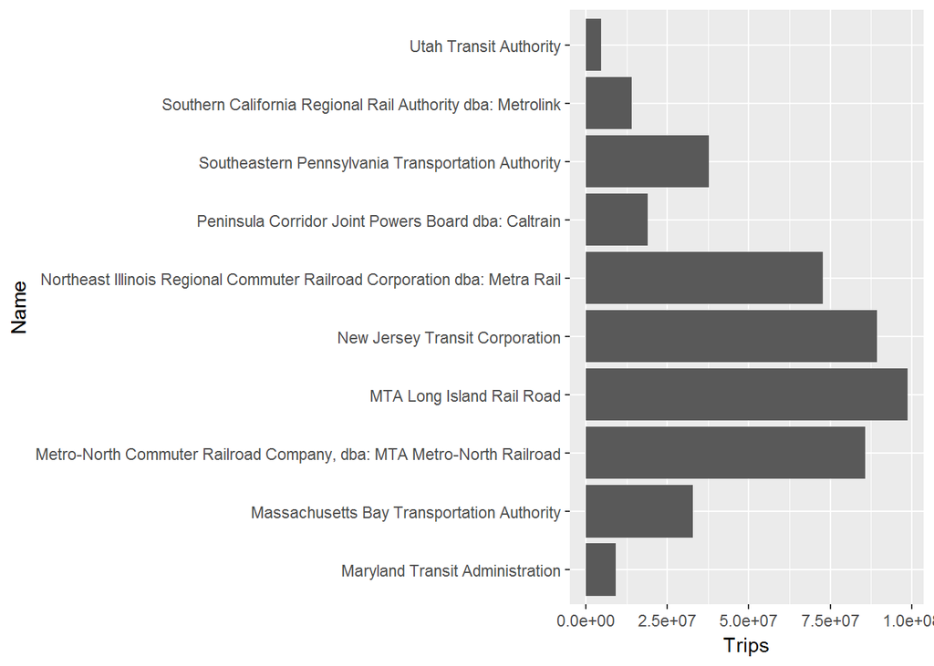

Another interesting visualization would be to compare each operator’s ridership in respect to the mean. The graph below presents that:

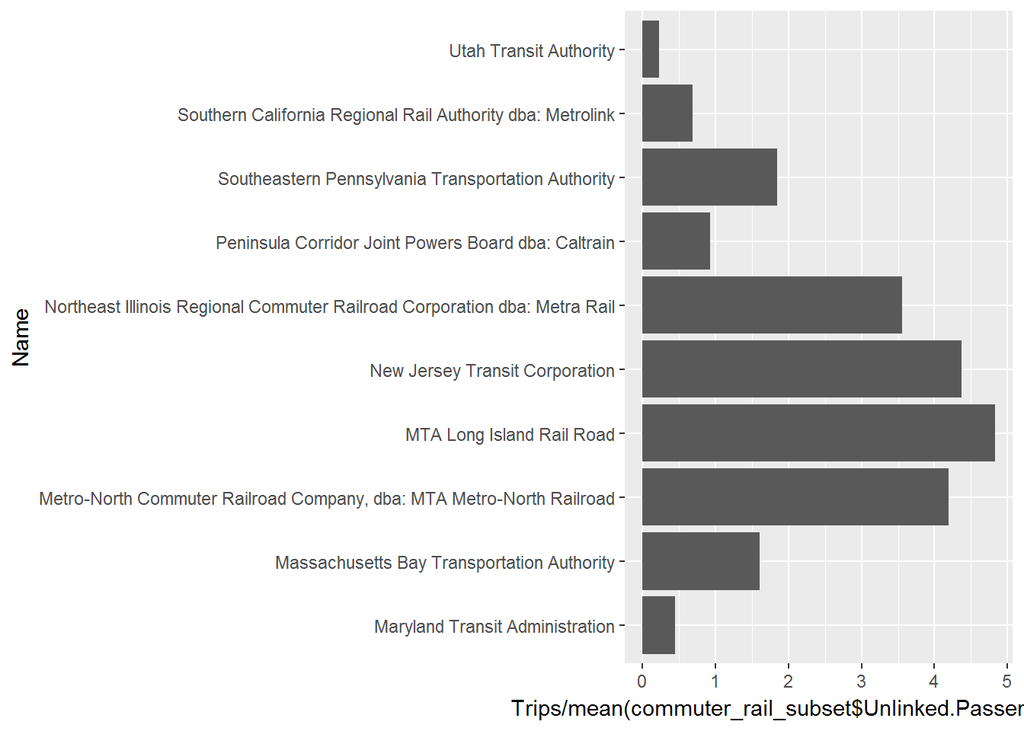

The graph above indicates that NYC Commuter Rail operators have significantly higher ridership when compared to the mean ridership in the US. Below we present the mean and the median for Commuter Rail Unlinked Trips:

```r
mean(commuter_rail_subset$Unlinked.Passenger.Trips)
```

```
## [1] 20448735
```

```r
median(commuter_rail_subset$Unlinked.Passenger.Trips)
```

```
## [1] 4072268
```

The mean and the mediam above are quite different, indicating that a few operators have very high ridership while most of them have low numbers. This can be confirmed in the histogram below:

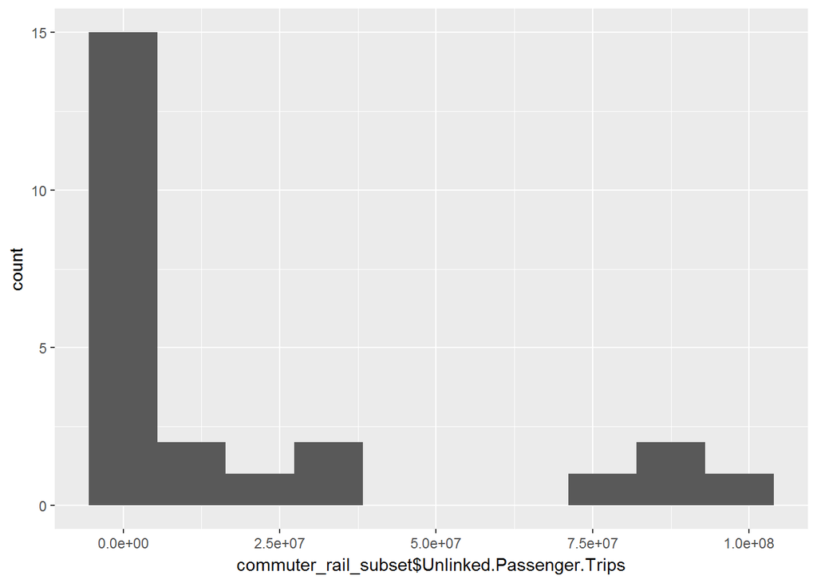

The bar chart below presents the top 10 Commuter Rail Revenue Miles. That is the number of miles travelled by trains while in revenue service.

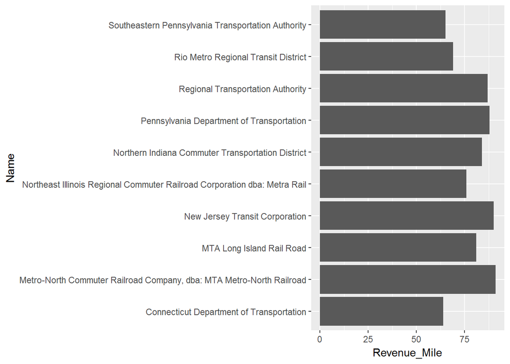

Comparing the graphs, New York City agencies are in top in all of them. However, differences on the previous graph are lower, indicating that several commuter rail operators travel similar number of miles but carrying significantly different number of passengers.

## Bus

In this section the Bus mode will be analysed. The graph below presents the top 10 bus operators in the US.

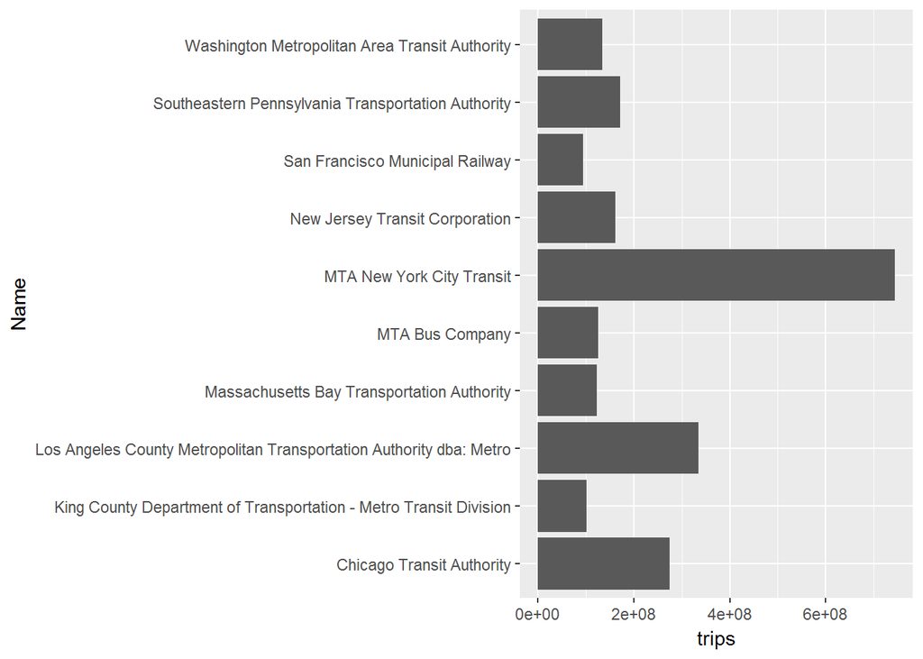

The plots below explore the number of vehicles variable. The first graph presents the top 10 agencies grouped by number of vehicles while the second is a histogram of agencies grouped by number of vehicles.

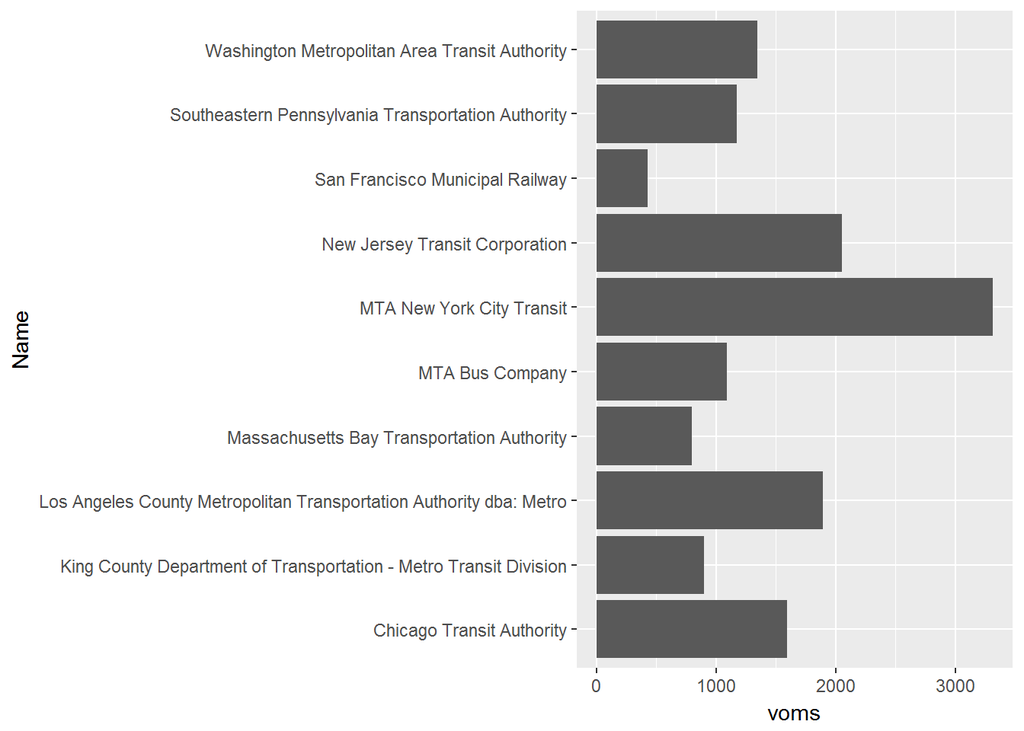

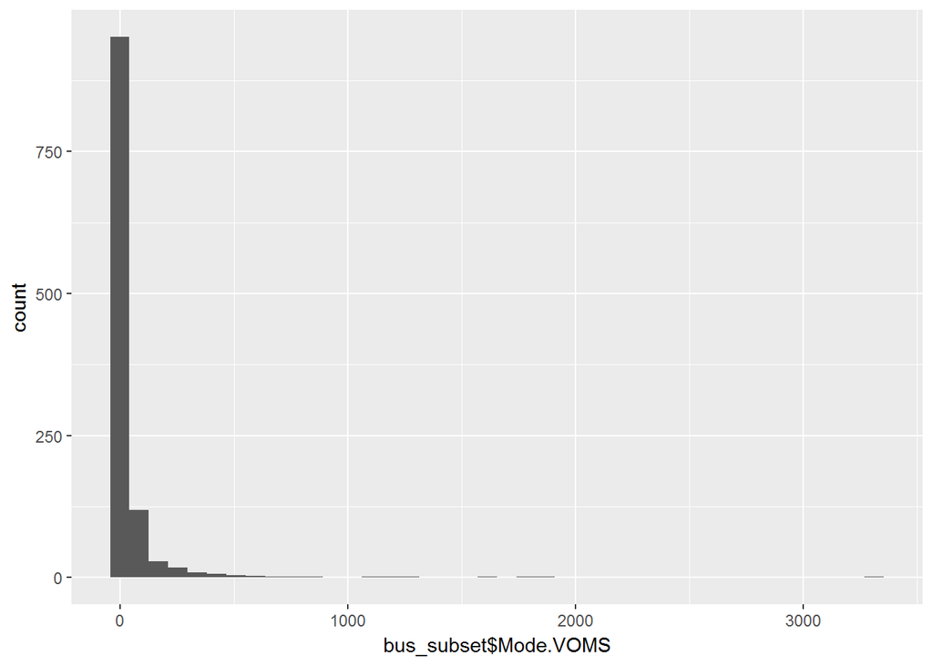

The trips and number of vehicles bar charts indicate that there is a relationship between both variables. Which can be confirmed in the scatter plot below:

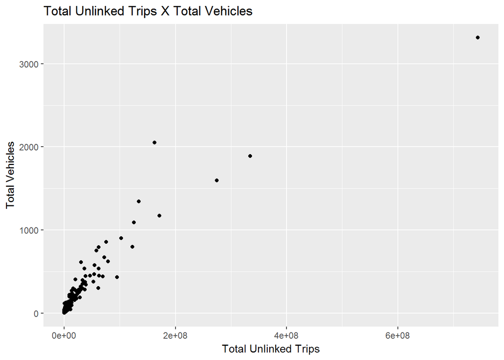

And the correlation is confirmed with Pearson’s test:

```r
cor.test(bus_by_agency$trips,bus_by_agency$voms,
         method = "pearson")
```

```
##
##  Pearson's product-moment correlation
##
## data:  bus_by_agency$trips and bus_by_agency$voms
## t = 83.211, df = 1093, p-value < 2.2e-16
## alternative hypothesis: true correlation is not equal to 0
## 95 percent confidence interval:
##  0.9207898 0.9369921
## sample estimates:
##      cor
## 0.929337
```

The bar plot below shows how average bus speed varies across agencies:

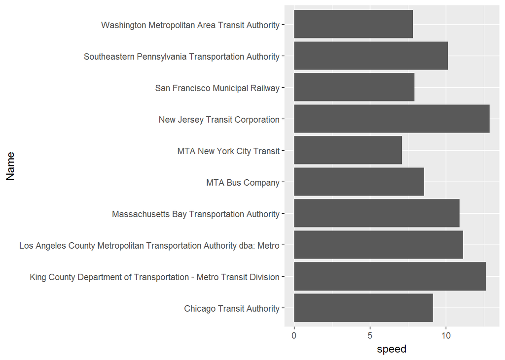

And is there a relationship between the average bus speed and the average passenger trip length?

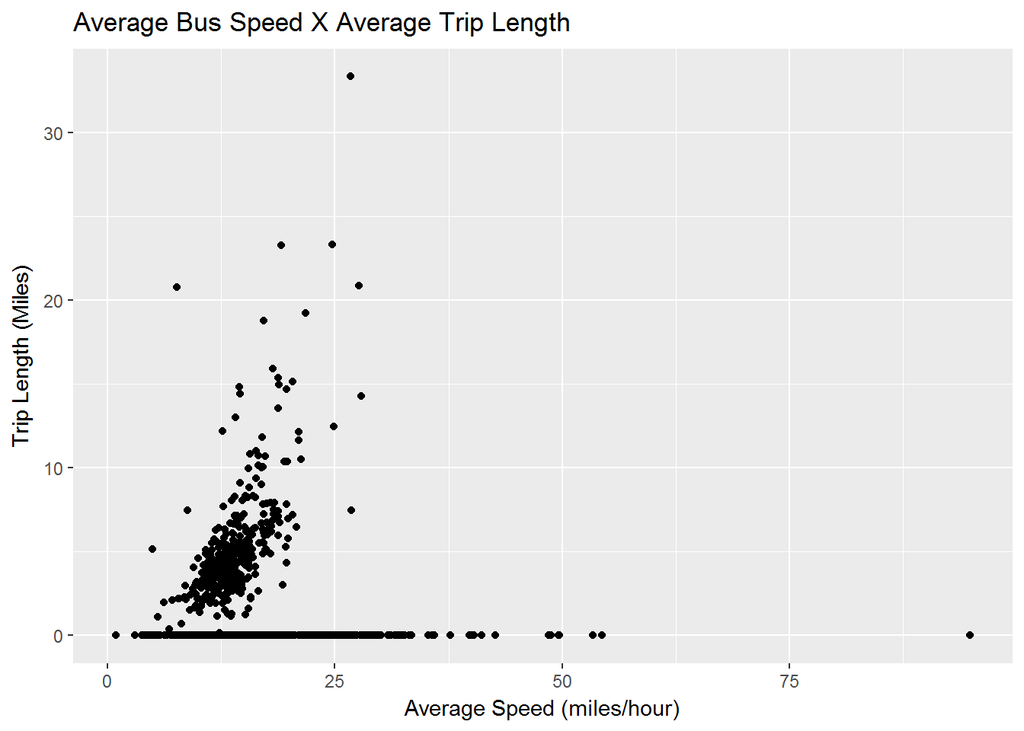

## Schedule Vs. Reality

Another interesting variables to look at are the Scheduled Vehicle Revenue Miles and Vehicle Revenue Miles. The first variable indicates the number of miles to be run by transit vehicles while in revenue service according to the schedule while the second variable presents the actual number of miles ran.

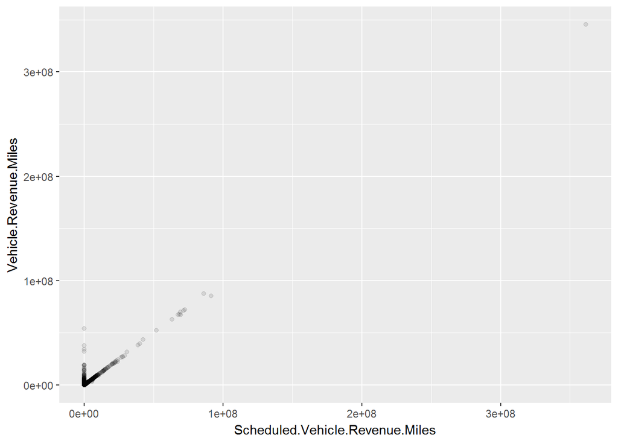

The scatter plot above shows that both variables are related, but as expected, the number of miles acutally ran is higher than scheduled for several transit agencies.

## Final Plots and Summary

In this section, three graphs shown previously have been polished.

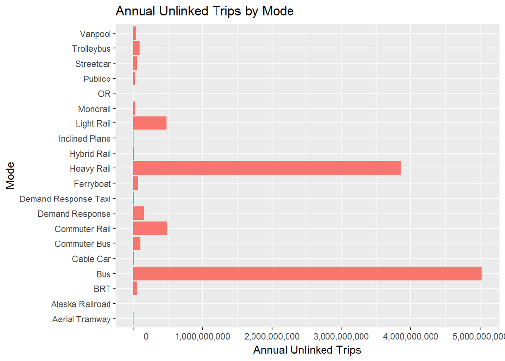

The plot below shows the top 10 cities by unlinked trips. Note that New York City is has the most transit trips in the US with a significant difference when compared to the other cities.

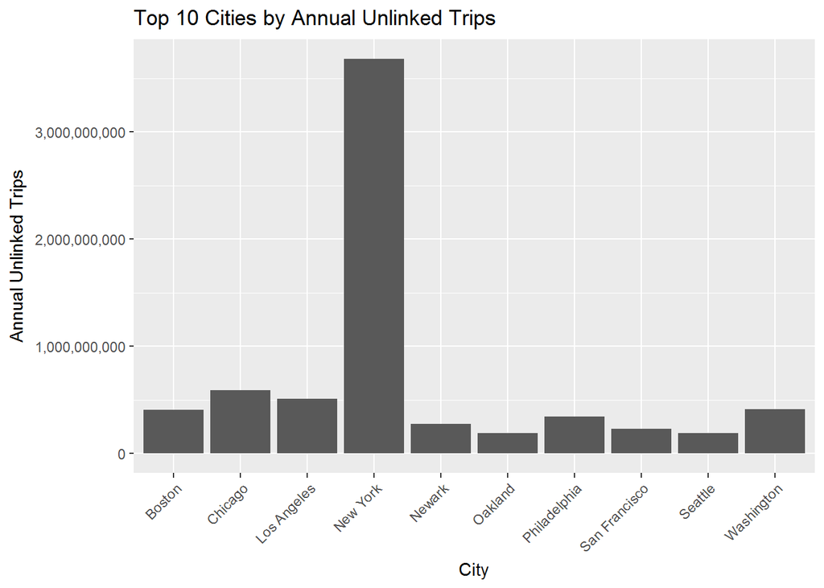

The scatter plot below compares Schedules, Actual Vehicle Revenue Miles and the Average Trip Length. Scheduled Revenue Miles correspond to the amount of miles transit vehicles run as planned on the timetables, while Actual Revenue Miles correspond to the miles that the transit vehicles actually ran. A logarithm transformation was applied for all variables in an attempt to better represent the data. The graph shows that the vehicle miles variables are strongly related and for most transit operators both variables have similar values. However, the graph indicates that the average trip length is not dependent to the vehicle revenue miles variables.

Note that for some transit agencies the data is incomplete, either missing one or both of the variables. Because of this there are several points on the y axis where x is equal to zero.

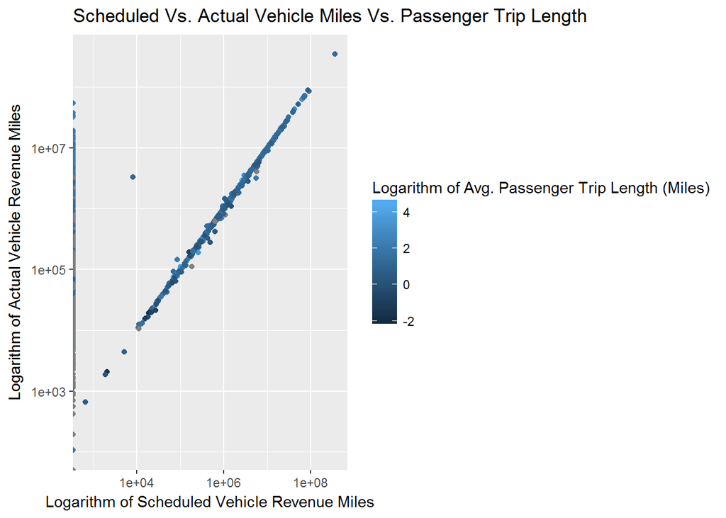

## Reflection

The NTD data provides several metrics that can be used to compare different transit operators across the US. This metrics can be use to evaluate the performance and quality of the service provided. The number of variables provided by the dataset is large and only a few of these variables were selected for analysis.

An interesting observation shown in this work is that the New York City Metropolitan area is the primary transit market in the US. Several of the graphs in this project have shown this. The city is first place in transit ridership with a signficant difference when compared to other cities.

One of the issues noticed while working with this data is that for some transit operators the data is incomplete, for example, there are several agencies which the passenger miles variable is zero, which implies that this data is not available.

The data used in this project correspond to a snapshot of 2015. The NTD also provides data for previous years, and for future work this data could be be used to evaluate the performance of these transit agencies across time. Also, the data includes several variables that were unexplored, and other modes besides Commuter Rail and Bus could be analysed.